# Swiftkey Data Product Introduction

Chuong Hoang  
Apr 05, 2016

*The presentation is for introducing a **Swiftkey data product** that enable to predict the next word that user intends to type. The data product is the capstone project for the **Coursera Data Science** specialization provided by the **Johns Hopkins University***

[figure not shown]

### Objectives of the Application

There are 4 main objectives of this Swiftkey Predictive Apllication are:

- Leverage [Social English Datasets](https://d396qusza40orc.cloudfront.net/dsscapstone/dataset/Coursera-SwiftKey.zip) *(blogs, news, twitter;~556 MB)* for terms frequency study
- The predictive algorithm have to make sure near-realtime respone, with responding time must **lower than 1 second**
- The application has to **maintain two responding approaches**: with and without English Stop Word.
- Not only provide a predicted word (most frequent appeared word following user input terms), the application also **return other possible options** ranking by n-gram and its frequency.

### Predictive Model of the Application

Principles of Modeling Approach are summarized in below diagram:

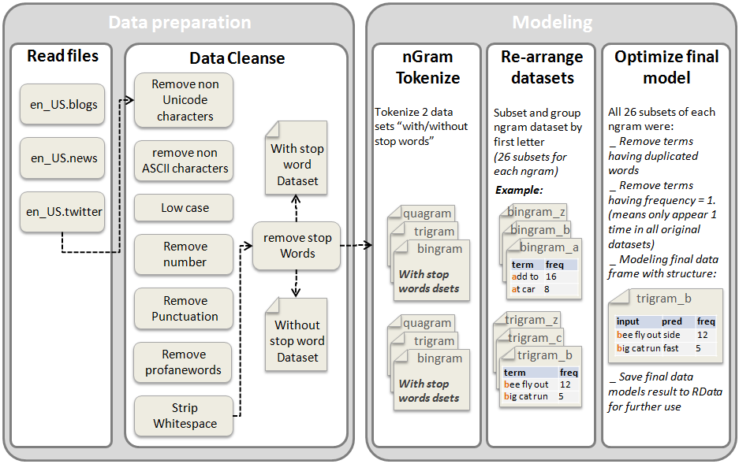

### How to work with the Application

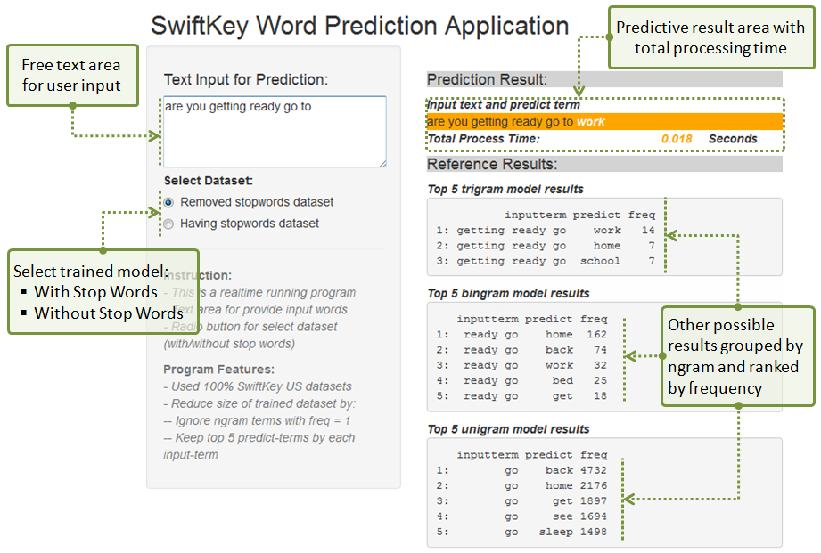

### Additional information

The Swiftkey Predictive Apllication is hosted at [chuonghdh.shinyapps.io](https://chuonghdh.shinyapps.io/SwiftKey_Project/)

The Detail of data preparation and algorithm modeling can access at [modeling sources](https://github.com/chuonghdh/SwiftKey_Project/tree/master/01_modeling)

The Detail of shiny app development can access at [shiny sources](https://github.com/chuonghdh/SwiftKey_Project/tree/master/02_shiny_app)

This pitch deck is hosted at [rpubs.com](http://rpubs.com/chuonghdh/DSCapstoneProject_pitch_deck)

The Capstone Project Milestone Report is hosted at [Project Milestone Report](http://rpubs.com/chuonghdh/Capstone_Project-Milestone_Report)

Learn more about the Coursera Data Science Specialization at [Data Science](https://www.coursera.org/specializations/jhu-data-science)

Source of profane words is located at [profanity list](https://gist.github.com/ryanlewis/a37739d710ccdb4b406d#file-google_twunter_lol)

**PS: Thanks for your reviewing, Please hire me for your own data science startup company :)**